# Custom-built functions

Daniel Kaplan

In this section, you’ll explore some of the properties of splines and a couple of other types of interpolating function.

To simplify, we’ll package code of the sort you encountered in the Kepler exercise into a mouse-driven app, [here](https://maa-statprep.shinyapps.io/142Z-Interpolation).

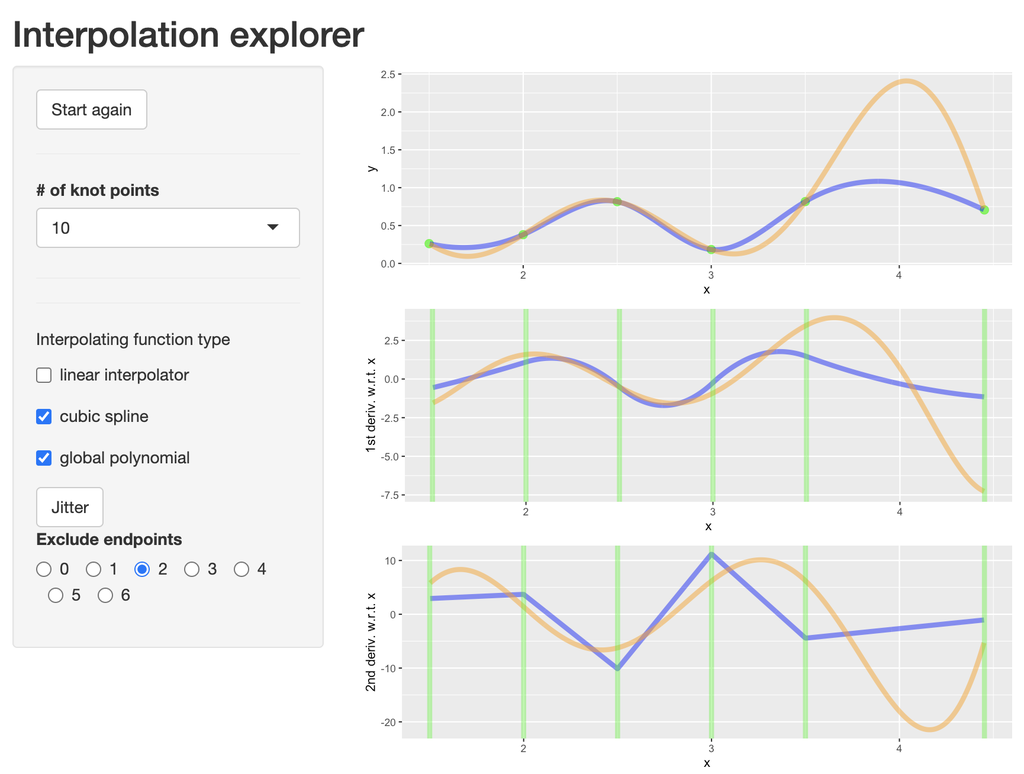

When you start the app, it will display in the top graph a small set of randomly generated data points. These are called **knot points*; the points the interpolator is bound to go through.

There are three types of interpolating functions on offer:

1. A piecewise-linear interpolator, which merely connects the knots with straight-line segments.
2. A cubic-spline interpolator, which is for good reason the most widely used in practice.
3. A global polynomial interpolator. For $n$ knots, an $n-1$ order polynomial suffices to connect the dots smoothly.

Pressing “Start again” generates a new set of knots. You can also select the number of knots to use.

The top graphic shows the knot points and any of the interpolators you have chosen to display.

The middle graph shows the first derivative with respect to $x$ of the interpolating functions. The last graph (if displayed) shows the 2nd derivative with respect to $x$.

There is also a control that allows you to narrow the region of display to exclude the first and last of the knots. All the knots are still being used to construct the interpolants, but only the middle segment of the interpolants is displayed.

When you start the app, five randomly generated knots are shown together with the straight-line interpolating function.

**Question tmp-1**: True or False: The segments of the straight-line interpolator never go beyond the vertical interval defined by the two knots being connected.

1. TRUE (+) []
2. FALSE []

**Question tmp-2**: All of these terms, **except one**, describe the first derivative (with respect to $x$) of the straight-line interpolant. Which one doesn’t fit?

1. Discontinuous []
2. Piecewise-constant []
3. Smooth (+) []

Turn on the display of the cubic-spline interpolator.

**Question tmp-3**: True or False: The segments of the cubic-spline interpolator never go outside the vertical interval defined by the two knots being connected.

1. True []
2. False (+) []

**Question tmp-4**: True or False: The first derivative (with respect to $x$) of the cubic-spline is continuous.

1. True (+) []
2. False []

**Question tmp-5**: True or False: The second derivative (with respect to $x$) of the cubic-spline is continuous.

1. True (+) [Remember, “continous” corresponds to being able to draw the graph without lifting the pencil from the paper.]
2. False []

**Question tmp-6**: True or False: The **third derivative** (with respect to $x$) of the cubic-spline is continuous.

1. True []
2. False (+) [The third derivative can be inferred from the second. Since the second consists of piecewise linear segments, the third derivative will be unconnected piecewise constant segments.]
3. Trick question []

Now turn on the display of the global polynomial interpolator. (You can turn off the cubic-spline display.)

**Question tmp-7**: True or False: The first derivative of the global polynomial is continous.

1. True (+) []
2. False []

**Question tmp-8**: True or False: The second derivative of the global polynomial is continuous.

1. True (+) []
2. False []

**Question tmp-9**: True or False: The **third derivative** of the global polynomial is continous.

1. True (+) []
2. False []
3. Trick question []

**Question tmp-10**: Which is the highest-order derivative of the global polynomial that is continous? (Work with 5 knots.)

1. 3 []
2. 4 []
3. 5 []
4. 10 []
5. $\infty$ (+) [All polynomials can be differentiated an infinite number of times. For an nth-order polynomial, the nth derivative is a constant function, and higher derivatives are the zero function. Boring, but continuous.]